# Missão R: Musicoterapia

Iara Cristina Mescua Castro

2023-04-10

## Contexto

Musicoterapia, ou MT, é o uso da música para melhorar o estresse, o humor e a saúde mental geral de um indivíduo. A MT também é reconhecida como uma prática baseada em evidências, usando a música como catalisadora de hormônios “felizes”, como a oxitocina.

No entanto, o MT emprega uma ampla gama de gêneros diferentes, variando de uma organização para outra.

O conjunto de dados “MxMH” visa identificar quais correlações, se houver, existem entre o gosto musical de um indivíduo e sua saúde mental autodeclarada. Idealmente, essas descobertas poderiam contribuir para uma aplicação mais informada da MT ou simplesmente fornecer visões interessantes sobre a mente.

## Dados Faltantes

Sumário de dados NA (Not Avaliable) que são diferentes de 0 no nosso dataset em cada coluna.

```
##                       Age Primary streaming service             While working
##                         1                         1                         3
##           Instrumentalist                  Composer         Foreign languages
##                         4                         1                         4
##                       BPM             Music effects
##                       107                         8
```

Das colunas acima, iremos utilizar “Age”, “Primary Streaming Service” e “Music effects”, aplicando filtros para desconsiderar linhas com dados NA em cada ocasião. Já BPM (batimentos por minuto) possui um número significativo de NA então não será levado em consideração.

## Horas e Idade

Vamos começar extraindo dados sobre o nosso grupo de estudo. Vamos ver como os fatores “idade” e “quantas horas por dia os usuários escutam música por dia” aparecem.

### Estatística Descritiva

```
##       Age        Hours per day         Intervalos
##  Min.   :10.00   Min.   : 0.000   0-2 Horas :165
##  1st Qu.:18.00   1st Qu.: 2.000   2-4 Horas :299
##  Median :21.00   Median : 3.000   4-6 Horas :138
##  Mean   :25.21   Mean   : 3.573   6-24 Horas:134
##  3rd Qu.:28.00   3rd Qu.: 5.000
##  Max.   :89.00   Max.   :24.000
##  NA's   :1
```

### Análise Quantitativa

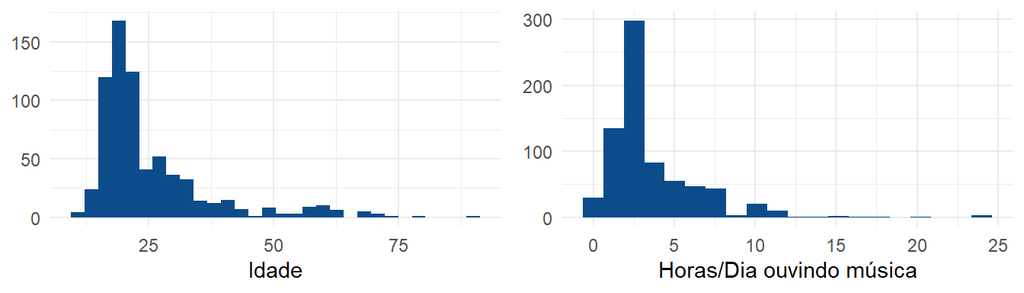

## Distribuição Idade x Gênero Musical

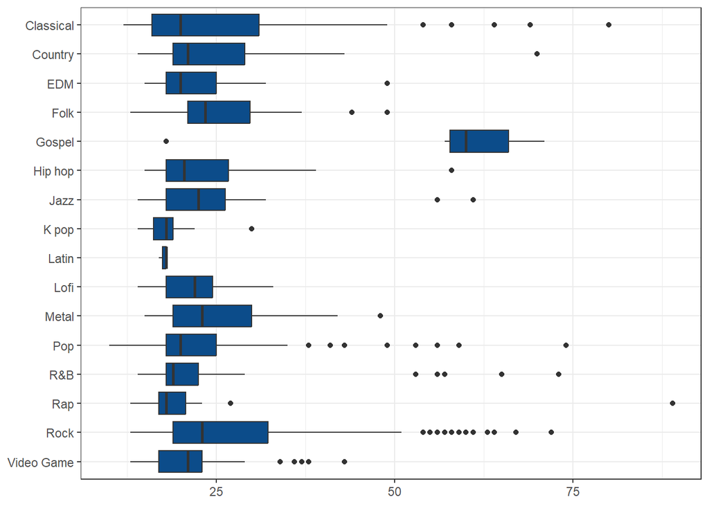

Os gêneros musicais favoritos podem se relacionar à idade, visto que a popularidade do Gospel é maior entre os idosos.

## Doenças Mentais

Neste dataset, os entrevistados classificam Ansiedade, Depressão, TOC (OCD) e Insônia em uma escala de 0 a 10, onde:  
0 - Eu não sinto isso.  
10 - Eu experimento isso regularmente, constantemente/ou ao extremo.

Com base nisso podemos começar observando algumas informações sobre cada uma.

### Estatística Descritiva

```
##     Anxiety         Depression          OCD            Insomnia
##  Min.   : 0.000   Min.   : 0.000   Min.   : 0.000   Min.   : 0.000
##  1st Qu.: 4.000   1st Qu.: 2.000   1st Qu.: 0.000   1st Qu.: 1.000
##  Median : 6.000   Median : 5.000   Median : 2.000   Median : 3.000
##  Mean   : 5.838   Mean   : 4.796   Mean   : 2.637   Mean   : 3.738
##  3rd Qu.: 8.000   3rd Qu.: 7.000   3rd Qu.: 5.000   3rd Qu.: 6.000
##  Max.   :10.000   Max.   :10.000   Max.   :10.000   Max.   :10.000
```

### Correlação

Em seguida, iremos plotar a correlação entre as doenças.

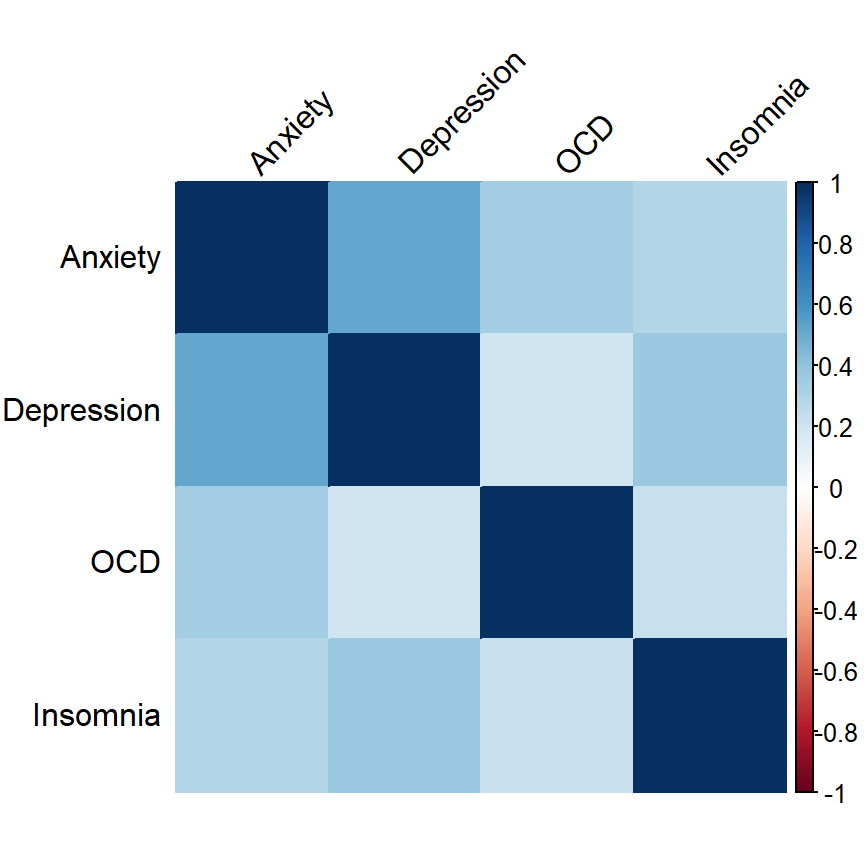

Há correlação positiva em todos os casos. Ao ter uma doença há maior tendência em ter outra, especialmente entre ansiedade e depressão.

### Distribuição Gênero Musical x Doenças

A seguir, está a distribuição das doenças para cada doença mental.

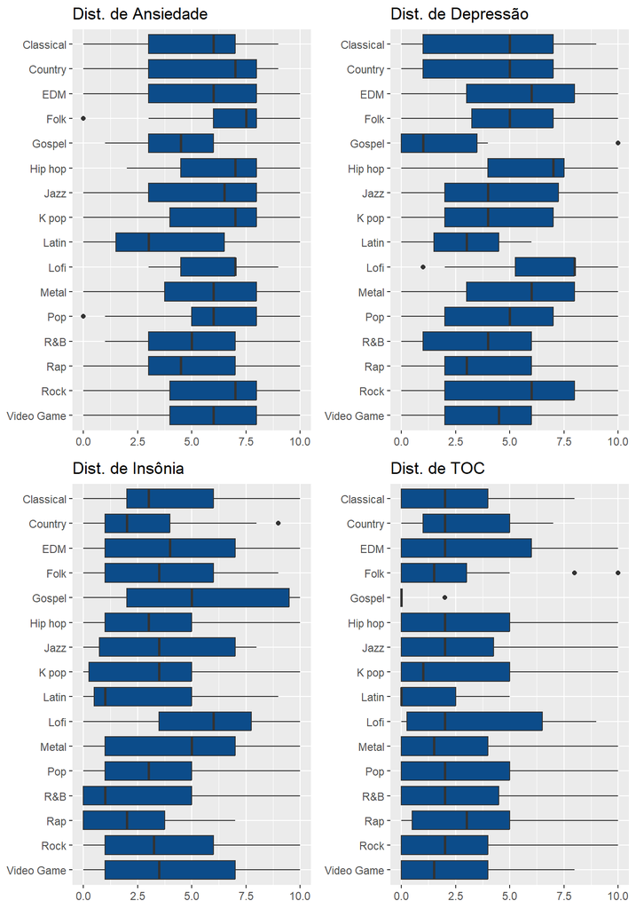

## Efeitos da Música

Os entrevistados também responderam qual efeito a música teve em sua saúde mental com as respostas “Pior”, “Melhor”, “Nenhum efeito”.

### Preferências Musicais e de Streaming

Antes disso, vamos verificar as preferências de gênero musical e os serviços de streaming mais utilizados por eles.

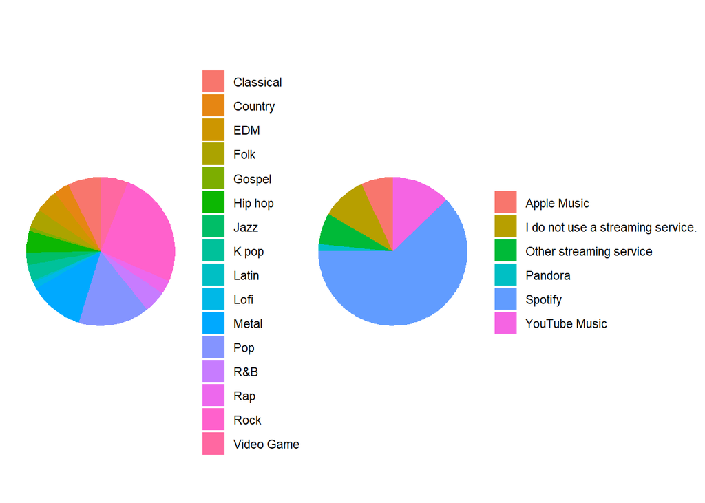

Observamos que o gênero musical favorito do grupo de estudo é o rock, seguido pelo pop e metal. Já o serviço de Streaming mais utilizado é o Spotify. Os gêneros musicais não estão bem distribuídos, então para a próxima análise levaremos em conta as porcentagens e não a quantidade bruta.

### Relação Efeitos da Música x Gênero Musical

Vamos observar os efeitos da música tomando a porcentagem de cada grupo, assim superamos as diferenças de quantidade entre os ouvintes de cada gênero musical.

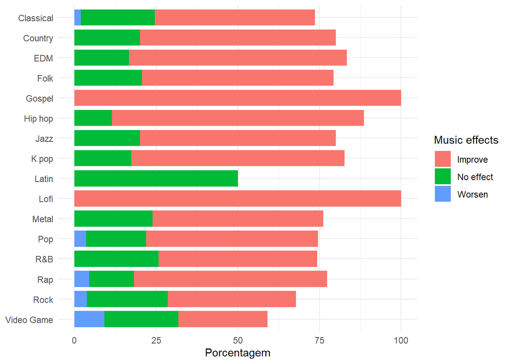

## Conclusões

Foi possível conhecer mais sobre os perfis dos ouvintes de música: a maioria são jovens, ouvem música via Spotify e seus 3 principais gêneros musicais são rock, pop e metal. E também, Gospel é predominante entre os idosos. Em suma, mais pessoas têm ansiedade e depressão do que TOC e insônia, onde existem correlações entre ansiedade e depressão. Não foi fácil inferir o estado de saúde mental a partir dos dados, mas vimos que a maioria dos ouvintes acha que a música melhora sua saúde mental e é notável a ausência de efeitos negativos para quem prefere “Lo-fi” e “Gospel”.

## Referências

1. https://www.kaggle.com/datasets/catherinerasgaitis/mxmh-survey-results